# FordGoBike Dataset Exploration

## Introduction

> The FordGoBike data is a dataset that includes the information if individual rides taks in a bike sharing system in the san francisco Bay area. They offer all residents of the Bay Area an affordable, accessible, and fun new transportation option. Anyone who has access to the membership has thousands of bikes across San Francisco, the East Bay and San Jose to choose from.

> Lyft has provided the data system for public to download. Each trip is includes:Trip Duration (seconds), Start Time and Date,End Time and Date, Start Station ID ,Start Station Name, Start Station Latitude Start Station Longitude, End Station ID ,End Station Name ,End Station Latitude, End Station Longitude, Bike ID, User Type, (Subscriber or Customer – “Subscriber” = Member or “Customer” = Casual), Member Year of Birth,Member Gender. In the following work, we will wrangle, assess, store, and visualize our findings.

## Preliminary Wrangling

```python
# import all packages and set plots to be embedded inline
import numpy as np
import pandas as pd
import matplotlib.pyplot as plt
import seaborn as sns

%matplotlib inline


import pandas as pd
import numpy as np
import matplotlib
from matplotlib import pyplot as plt
import matplotlib.ticker as tick
import seaborn as sns
import datetime
import math
import calendar
import warnings
warnings.filterwarnings('ignore')
from IPython.display import Image
%matplotlib inline
```

> Load in your dataset I saved and uploaded the dataset from the Udacity Data List to the jupyter Notebook

```python
# We will Read the CSV File
df =pd.read_csv('fordgobike.csv')
df.head()
```

|  | duration_sec | start_time | end_time | start_station_id | start_station_name | start_station_latitude | start_station_longitude | end_station_id | end_station_name | end_station_latitude | end_station_longitude | bike_id | user_type | member_birth_year | member_gender | bike_share_for_all_trip |
| --- | --- | --- | --- | --- | --- | --- | --- | --- | --- | --- | --- | --- | --- | --- | --- | --- |
| 0 | 75284 | 2018-01-31 22:52:35.2390 | 2018-02-01 19:47:19.8240 | 120 | Mission Dolores Park | 37.761420 | -122.426435 | 285 | Webster St at O'Farrell St | 37.783521 | -122.431158 | 2765 | Subscriber | 1986.0 | Male | No |
| 1 | 85422 | 2018-01-31 16:13:34.3510 | 2018-02-01 15:57:17.3100 | 15 | San Francisco Ferry Building (Harry Bridges Pl... | 37.795392 | -122.394203 | 15 | San Francisco Ferry Building (Harry Bridges Pl... | 37.795392 | -122.394203 | 2815 | Customer | NaN | NaN | No |
| 2 | 71576 | 2018-01-31 14:23:55.8890 | 2018-02-01 10:16:52.1160 | 304 | Jackson St at 5th St | 37.348759 | -121.894798 | 296 | 5th St at Virginia St | 37.325998 | -121.877120 | 3039 | Customer | 1996.0 | Male | No |
| 3 | 61076 | 2018-01-31 14:53:23.5620 | 2018-02-01 07:51:20.5000 | 75 | Market St at Franklin St | 37.773793 | -122.421239 | 47 | 4th St at Harrison St | 37.780955 | -122.399749 | 321 | Customer | NaN | NaN | No |
| 4 | 39966 | 2018-01-31 19:52:24.6670 | 2018-02-01 06:58:31.0530 | 74 | Laguna St at Hayes St | 37.776435 | -122.426244 | 19 | Post St at Kearny St | 37.788975 | -122.403452 | 617 | Subscriber | 1991.0 | Male | No |

```python
#Get information about the  coulmn.
df.info()
```

```
<class 'pandas.core.frame.DataFrame'>
RangeIndex: 94802 entries, 0 to 94801
Data columns (total 16 columns):
duration_sec               94802 non-null int64
start_time                 94802 non-null object
end_time                   94802 non-null object
start_station_id           94802 non-null int64
start_station_name         94802 non-null object
start_station_latitude     94802 non-null float64
start_station_longitude    94802 non-null float64
end_station_id             94802 non-null int64
end_station_name           94802 non-null object
end_station_latitude       94802 non-null float64
end_station_longitude      94802 non-null float64
bike_id                    94802 non-null int64
user_type                  94802 non-null object
member_birth_year          86963 non-null float64
member_gender              87001 non-null object
bike_share_for_all_trip    94802 non-null object
dtypes: float64(5), int64(4), object(7)
memory usage: 9.0+ MB
```

```python
#to understand the size of the dataser
df.shape
```

```
(94802, 16)
```

```python
# Check if there is any null value in the data frame
# We can see that member_birth_year contains 7839 and member_gender contains 7801
df.isnull().sum()
```

```
duration_sec                  0
start_time                    0
end_time                      0
start_station_id              0
start_station_name            0
start_station_latitude        0
start_station_longitude       0
end_station_id                0
end_station_name              0
end_station_latitude          0
end_station_longitude         0
bike_id                       0
user_type                     0
member_birth_year          7839
member_gender              7801
bike_share_for_all_trip       0
dtype: int64
```

```python
# we will understand the stats figures
df.describe()
```

|  | duration_sec | start_station_id | start_station_latitude | start_station_longitude | end_station_id | end_station_latitude | end_station_longitude | bike_id | member_birth_year |
| --- | --- | --- | --- | --- | --- | --- | --- | --- | --- |
| count | 94802.000000 | 94802.000000 | 94802.000000 | 94802.000000 | 94802.00000 | 94802.000000 | 94802.000000 | 94802.000000 | 86963.000000 |
| mean | 870.935930 | 103.766302 | 37.773321 | -122.361677 | 101.00982 | 37.773536 | -122.360776 | 2048.751609 | 1980.932420 |
| std | 2550.596891 | 87.730464 | 0.085744 | 0.105253 | 86.77949 | 0.085552 | 0.104580 | 1091.507513 | 10.803017 |
| min | 61.000000 | 3.000000 | 37.317298 | -122.444293 | 3.00000 | 37.317298 | -122.444293 | 11.000000 | 1900.000000 |
| 25% | 359.000000 | 30.000000 | 37.771662 | -122.412408 | 27.00000 | 37.773063 | -122.411306 | 1133.000000 | 1975.000000 |
| 50% | 555.000000 | 79.000000 | 37.781270 | -122.398773 | 76.00000 | 37.781752 | -122.398436 | 2151.500000 | 1983.000000 |
| 75% | 854.000000 | 160.000000 | 37.795392 | -122.390428 | 157.00000 | 37.795392 | -122.390428 | 3015.000000 | 1989.000000 |
| max | 85546.000000 | 342.000000 | 37.880222 | -121.874119 | 342.00000 | 37.880222 | -121.874119 | 3744.000000 | 2000.000000 |

```python
# To check if we have any duplicates
df.duplicated()
```

```
0        False
1        False
2        False
3        False
4        False
5        False
6        False
7        False
8        False
9        False
10       False
11       False
12       False
13       False
14       False
```

[output cut: 47 more lines]

#### Initial Observation (Quality Check)

> Eventhough the dataset doesnt have duplicate, I have noticed these issues.
> - We have Timestamp format issues (start_time, end_time )
> - we have Data type issues (like member_birth, Member_gender, start_station,bike_id, Birthdates)

> Eventhough we have missing data issues in the members_gender and Member_birth_year, i believe that it would not affect my analysis so i didnt clean them.

### Cleaning Data

```python
# We will start by Creating a Copy of the orginal file
df_clean = df.copy()
```

#### Issue 1 : We have Timestamp format issues (start_time, end_time )

#### DEFINE

For the start_time and End_time, we can see that it is not in the datetime format. So in this section we will convert it to datetime format

#### CODE

```python
#convert to the datetime format
df_clean.start_time = pd.to_datetime(df_clean.start_time)
df_clean.end_time = pd.to_datetime(df_clean.end_time)
```

#### TEST

```python
# To Double check that it is converted
df_clean.info()
```

```
<class 'pandas.core.frame.DataFrame'>
RangeIndex: 94802 entries, 0 to 94801
Data columns (total 16 columns):
duration_sec               94802 non-null int64
start_time                 94802 non-null datetime64[ns]
end_time                   94802 non-null datetime64[ns]
start_station_id           94802 non-null int64
start_station_name         94802 non-null object
start_station_latitude     94802 non-null float64
start_station_longitude    94802 non-null float64
end_station_id             94802 non-null int64
end_station_name           94802 non-null object
end_station_latitude       94802 non-null float64
end_station_longitude      94802 non-null float64
bike_id                    94802 non-null int64
user_type                  94802 non-null object
member_birth_year          86963 non-null float64
member_gender              87001 non-null object
bike_share_for_all_trip    94802 non-null object
dtypes: datetime64[ns](2), float64(5), int64(4), object(5)
memory usage: 9.8+ MB
```

> We can see that it is changed from the object type to datetime format

#### CODE

```python
# I want to create more start_time different time reference
df_clean['start_time_weekday'] = df_clean['start_time'].dt.strftime('%a')
```

```python
#To Create the day from starttime
df_clean['start_time_day']=df_clean['start_time'].dt.day.astype(int)
```

```python
#To get the time hour from the time of the day
df_clean['start_time_hour']=df_clean['start_time'].dt.hour
```

#### TEST

```python
df_clean.sample(3)
```

|  | duration_sec | start_time | end_time | start_station_id | start_station_name | start_station_latitude | start_station_longitude | end_station_id | end_station_name | end_station_latitude | end_station_longitude | bike_id | user_type | member_birth_year | member_gender | bike_share_for_all_trip | start_time_weekday | start_time_day | start_time_hour |
| --- | --- | --- | --- | --- | --- | --- | --- | --- | --- | --- | --- | --- | --- | --- | --- | --- | --- | --- | --- |
| 23350 | 435 | 2018-01-25 17:19:37.729 | 2018-01-25 17:26:53.314 | 341 | Fountain Alley at S 2nd St | 37.336188 | -121.889277 | 307 | SAP Center | 37.332692 | -121.900084 | 1859 | Subscriber | 1994.0 | Male | Yes | Thu | 25 | 17 |
| 16544 | 233 | 2018-01-27 17:11:08.616 | 2018-01-27 17:15:02.199 | 172 | College Ave at Taft Ave | 37.841800 | -122.251535 | 205 | Shafter Ave at Cavour St | 37.837947 | -122.257243 | 2581 | Subscriber | 1968.0 | Female | No | Sat | 27 | 17 |
| 196 | 202 | 2018-01-31 21:10:31.621 | 2018-01-31 21:13:53.840 | 171 | Rockridge BART Station | 37.844279 | -122.251900 | 170 | Telegraph Ave at 58th St | 37.844493 | -122.261351 | 154 | Subscriber | 1977.0 | Male | Yes | Wed | 31 | 21 |

#### Issue 2: we have Data type issues (like member_birth, Member_gender, start_station,bike_id, Birthdates)

#### DEFINE

I also noticed that different data type has object type, so below we will change it appropriate type

#### CODE

```python
#change the Bike_id, station_id, end_station_id to str
df_clean.bike_id = df_clean.bike_id.astype(str)
df_clean.start_station_id = df_clean.start_station_id.astype(str)
df_clean.end_station_id = df_clean.end_station_id.astype(str)

# change the user_type, member_gender, and bike_share_for_all to category
df_clean.user_type = df_clean.user_type.astype('category')
df_clean.member_gender = df_clean.member_gender.astype('category')
df_clean.bike_share_for_all_trip = df_clean.bike_share_for_all_trip.astype('category')
```

#### TEST

```python
df_clean.info()
# we can see that all the fields are converted to the str and category
```

```
<class 'pandas.core.frame.DataFrame'>
RangeIndex: 94802 entries, 0 to 94801
Data columns (total 19 columns):
duration_sec               94802 non-null int64
start_time                 94802 non-null datetime64[ns]
end_time                   94802 non-null datetime64[ns]
start_station_id           94802 non-null object
start_station_name         94802 non-null object
start_station_latitude     94802 non-null float64
start_station_longitude    94802 non-null float64
end_station_id             94802 non-null object
end_station_name           94802 non-null object
end_station_latitude       94802 non-null float64
end_station_longitude      94802 non-null float64
bike_id                    94802 non-null object
user_type                  94802 non-null category
member_birth_year          86963 non-null float64
member_gender              87001 non-null category
bike_share_for_all_trip    94802 non-null category
start_time_weekday         94802 non-null object
start_time_day             94802 non-null int32
start_time_hour            94802 non-null int64
dtypes: category(3), datetime64[ns](2), float64(5), int32(1), int64(2), object(6)
memory usage: 9.3+ MB
```

#### Cleaning the data more in order to get flexibility for analysis

#### Calculating the Age of members

```python
df_clean['age'] = 2018 - df_clean['member_birth_year']
```

```python
df_clean.age.mean()
```

```
37.06758046525534
```

```python
df_clean.age.describe(percentiles = [.95])
```

```
count    86963.000000
mean        37.067580
std         10.803017
min         18.000000
50%         35.000000
95%         57.000000
max        118.000000
Name: age, dtype: float64
```

> Here we can can see that the mean is 37 year and min is 18 but max is 118. so we have some issues.it also see that the 95% is 57. so we will remove all that is above 59.

#### CODE

```python
# we will only cover data below 59
df_clean = df_clean.query('age <= 59')
```

```python
df_clean.age = df_clean.age.astype(int)
df_clean.member_birth_year = df_clean.member_birth_year.astype(int)
```

#### TEST

```python
df_clean.describe()
```

|  | duration_sec | start_station_latitude | start_station_longitude | end_station_latitude | end_station_longitude | member_birth_year | start_time_day | start_time_hour | age |
| --- | --- | --- | --- | --- | --- | --- | --- | --- | --- |
| count | 83771.000000 | 83771.000000 | 83771.000000 | 83771.000000 | 83771.000000 | 83771.000000 | 83771.000000 | 83771.000000 | 83771.000000 |
| mean | 727.159924 | 37.773623 | -122.361421 | 37.773772 | -122.360437 | 1982.091858 | 17.520335 | 13.223407 | 35.908142 |
| std | 1809.510654 | 0.084971 | 0.104597 | 0.084742 | 0.103862 | 8.957783 | 8.870918 | 4.685302 | 8.957783 |
| min | 61.000000 | 37.317298 | -122.444293 | 37.317298 | -122.444293 | 1959.000000 | 1.000000 | 0.000000 | 18.000000 |
| 25% | 351.000000 | 37.771662 | -122.412408 | 37.772406 | -122.411306 | 1977.000000 | 10.000000 | 9.000000 | 29.000000 |
| 50% | 534.000000 | 37.781270 | -122.398525 | 37.781270 | -122.397405 | 1984.000000 | 18.000000 | 13.000000 | 34.000000 |
| 75% | 805.000000 | 37.795392 | -122.390428 | 37.795392 | -122.390428 | 1989.000000 | 25.000000 | 17.000000 | 41.000000 |
| max | 84609.000000 | 37.880222 | -121.874119 | 37.880222 | -121.874119 | 2000.000000 | 31.000000 | 23.000000 | 59.000000 |

```python
#More calculation to determine the distance of bike rides
#Generate new fields for distance
def distance(origin, destination):
    lat1, lon1 = origin
    lat2, lon2 = destination
    radius = 6371  # km

    dlat = math.radians(lat2 - lat1)
    dlon = math.radians(lon2 - lon1)
    a = (math.sin(dlat / 2) * math.sin(dlat / 2) +
         math.cos(math.radians(lat1)) * math.cos(math.radians(lat2)) *
         math.sin(dlon / 2) * math.sin(dlon / 2))
    c = 2 * math.atan2(math.sqrt(a), math.sqrt(1 - a))
    d = radius * c

    return d
```

```python
df['distance_km_estimates'] = df.apply(lambda x: distance((x['start_station_latitude'], x['start_station_longitude']), (x['end_station_latitude'], x['end_station_longitude'])), axis=1)
df['distance_miles_estimates'] = df['distance_km_estimates']*0.621371
```

```python
#### Storing the cleaned dataframe in CSV file
df_clean.to_csv('fordgo_master.csv',index = False)
```

### What is the structure of your dataset?

> The Dataset contains 94802 rows and 16 columns.The dataset is tidy and very easy to understand. From the 16 columns the members_geneder and members_birth_year seems to have null values. The data point i chose is recoded is in Juanuary 2018. The datapoint are the start time, end time, station longitude and latitude, bike id, user type, member year of birth and geender

### What is/are the main feature(s) of interest in your dataset?

> Since the data is straight forward and easy to understand, I am intrested in th different exploration datappoints.
> 1. what are the dependency in different user type, gender and age?
> 2. How long does the avergae trip will take or what is the duration?
> 3. When are the high and low demands?
> 4. When are the most trips taken interms of time of the day?
> 5. what is the most demand station based on station location?

### What features in the dataset do you think will help support your investigation into your feature(s) of interest?

> In Order to do the investigation, we will need the age, Distance, start time, end time , start station, End Station and user type. we will also need the gender.

## Univariate Exploration

> In this section, We will investigate distributions of individual variables. univariate means that we are going to explore variables one by one.

```python
# I want to see the mean or the stats figure about duration of trips
df_clean.duration_sec.describe()
```

```
count    83771.000000
mean       727.159924
std       1809.510654
min         61.000000
25%        351.000000
50%        534.000000
75%        805.000000
max      84609.000000
Name: duration_sec, dtype: float64
```

[figure not shown]

```python
# We want to look at the duration of the bike
duration_sec = np.random.randn(1000)
plt.hist(duration_sec)
plt.title("FordGoBike System Duration")
plt.xlabel("Duration-Sec")
plt.ylabel("Number of Bike Trips")
```

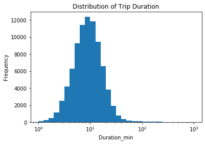

```python
#In order to understand the information, We will change the duration from sec to min
df_clean['duration_min'] = df_clean['duration_sec'] / 60
df_clean.drop('duration_sec' , axis = 1 , inplace = True)

#Plot the hist
bin_edges = 10**np.arange(0 , 3+0.1 , 0.1)
ticks =  [ 0.1 , 0.3 , 1 , 3, 10, 30, 100, 300]
labels = ['{}'.format(v) for v in ticks]
plt.hist(data = df_clean , x = 'duration_min' , bins = bin_edges);
plt.xticks(ticks,labels);
plt.xlabel('Duration_min');
plt.xscale('log');
plt.title('Distribution of Trip Duration')
plt.ylabel('Frequency')
```

> we can still see that most of the trips are taken for a short period of time. it is upto 10 min

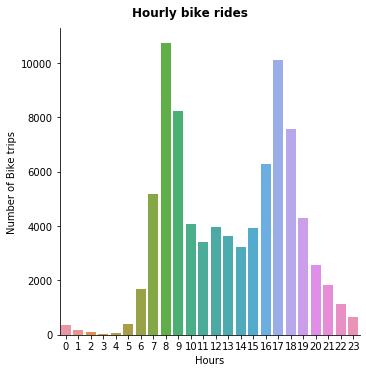

```python
gr= sns.catplot(data=df_clean,x='start_time_hour', kind= 'count')
gr.set_axis_labels('Hours', 'Number of Bike trips')
gr.fig.suptitle('Hourly bike rides', y=1.03, fontsize=12,fontweight='bold')
```

> This Beautiful Graph shows that the most ride taken is mainly between 8:00 am to 10:00 am. and also between 5pm to 7pm.

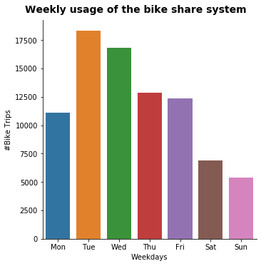

```python
#I also want to investigate the different weekday bike ride traffice
weekday = ['Mon', 'Tue', 'Wed', 'Thu', 'Fri', 'Sat', 'Sun']
g = sns.catplot(data=df_clean, x='start_time_weekday', kind='count', order = weekday)
g.set_axis_labels("Weekdays", "#Bike Trips")
g.fig.suptitle('Weekly usage of the bike share system', y=1.03, fontsize=14, fontweight='semibold');
```

> The fordGoBike sharing system is mostly used on the weekday, specially between tuesday to friday. The last two visualization shows me that this ride sharing system is mostly used by the working populations.

### Discuss the distribution(s) of your variable(s) of interest. Were there any unusual points? Did you need to perform any transformations??

> I didnt observe any unusual points in this section. we saw at the beginging of the observation that we had age range to 118, which didnt make sense. so we have selected the data to only show to 59

### Of the features you investigated, were there any unusual distributions? Did you perform any operations on the data to tidy, adjust, or change the form of the data? If so, why did you do this?

> Like mentioned in the above answer, the only unusual was the age so we have limited it to age range of 18 to 59

## Bivariate Exploration

> In this section, investigate relationships between pairs of variables in your data. Make sure the variables that you cover here have been introduced in some fashion in the previous section (univariate exploration). In this sections, I will dive into the information more into it by introuducing pair of Varibales

```python
# set the age and count the bike id
trip_by_age_df = df_clean.groupby('age').agg({'bike_id':'count'})
```

```python
#Calculate the percentile
trip_by_age_df['perc'] = (trip_by_age_df['bike_id']/trip_by_age_df['bike_id'].sum())*100
```

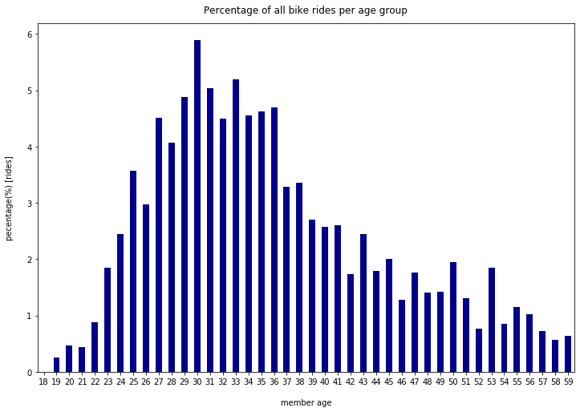

```python
# Visualize the information
new_color = ['darkblue']
trip_by_age_df['perc'].plot(kind='bar', color=new_color, figsize=(12,8))
plt.title('Percentage of all bike rides per age group', fontsize=12, y=1.015)
plt.xlabel('member age', labelpad=16)
plt.ylabel('pecentage(%) [rides]', labelpad=16)
plt.xticks(rotation=360)
plt.savefig('image05.png');
```

> In the above visualization, we are analyzing the percentage of ride take to the age groups. we learn from the above visualization that the most age group is between 29 to 37

### Percentage of all bike rides per gender

```python
trip_by_gender_df = df_clean.groupby('member_gender').agg({'bike_id':'count'})
```

```python
trip_by_gender_df['perc'] = (trip_by_gender_df['bike_id']/trip_by_gender_df['bike_id'].sum())*100
```

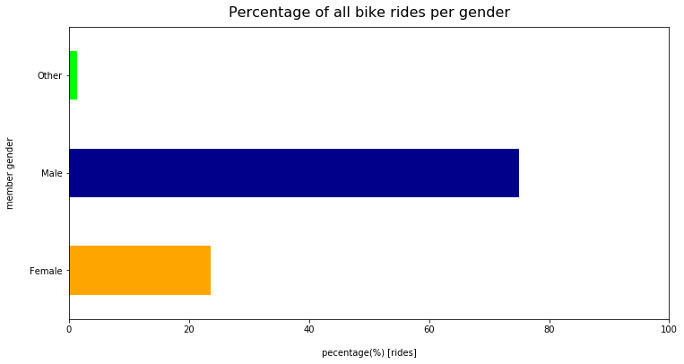

```python
new_color = ['Orange', 'darkblue', 'lime']
trip_by_gender_df['perc'].plot(kind='barh', color=new_color, figsize=(12,6))
plt.title('Percentage of all bike rides per gender', fontsize=16, y=1.015)
plt.ylabel('member gender', labelpad=16)
plt.xlabel('pecentage(%) [rides]', labelpad=16)
plt.xticks(rotation=360)
plt.xlim(0,100)
plt.savefig('image06.png');
```

> In the Above visiualization, we clearly see that the Male is the gender that uses the ridesharing system

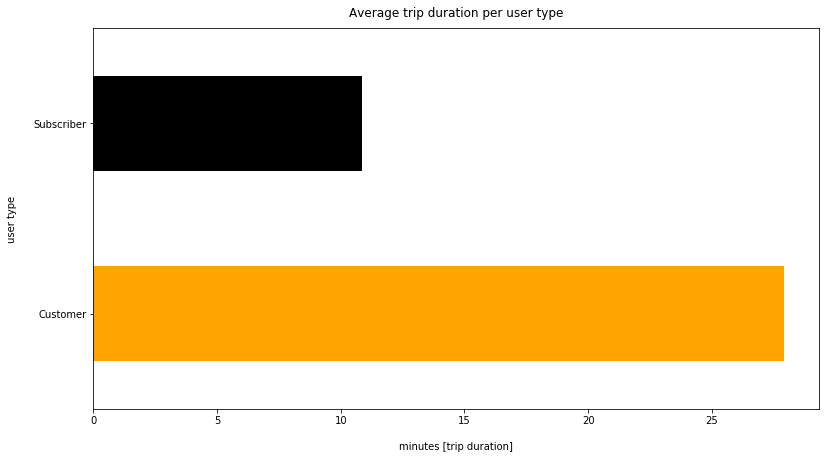

```python
new_color=['orange', 'black']
ax = df_clean.groupby('user_type')['duration_min'].mean().plot(kind='barh', color=new_color, figsize=(13,7))
ax.set_title('Average trip duration per user type', fontsize=12, y=1.015)
ax.set_ylabel('user type', labelpad=16)
ax.set_xlabel('minutes [trip duration]', labelpad=16)
```

> I wanted to visualize the different user type and the duration by min. The average trip taken by customers is greater than the subscriber

[figure not shown]

```python
gr = sns.catplot(data=df_clean, x='start_time_hour', col="user_type", kind='count', sharey = False)
gr.set_axis_labels("Hour", "Number of Bike Trips")
gr.set_titles("{col_name}")
gr.fig.suptitle('Hourly usage of the bike share system per user type', y=1.03, fontsize=12, fontweight='semibold');
```

> This is intresting finding. The above graph shows intresting trend. the customers and subscriber peak hours for renting starts at 8am but the difference here is the customer still continous to be high but for the subscriber, it sinks down between 10 till 4 pm. And picks back up at 5 pm.

### Talk about some of the relationships you observed in this part of the investigation. How did the feature(s) of interest vary with other features in the dataset?

> Adding the different type of data point makes the investigation intresting. I was able to observer the different gender and user type behavior. we saw that the male is the most user of the ride sharing system. We also noticed the different pattern of the usertype in different hours and also duration.

### Did you observe any interesting relationships between the other features (not the main feature(s) of interest)?

> I observed a couple of intresting behavior. The first one was the difference of duration of trip for customer and subscriber. it shows that the customers take the longest duuration than subscriber. I was assuming before digging into the data that subscribers would take the longest trip. the second intresting ovbservation has to be the different hours of customer and subscriber usage. i was still assuming that there will not be a big difference between customer and subscriber.

## Multivariate Exploration

> Create plots of three or more variables to investigate your data even further. Make sure that your investigations are justified, and follow from your work in the previous sections.

[figure not shown]

```python
# weekday usege of the bike sharing system per user type and gender

weekday = ['Mon', 'Tue', 'Wed', 'Thu', 'Fri', 'Sat', 'Sun']
gr = sns.catplot(data=df_clean, x='start_time_weekday', col="user_type", hue='member_gender', kind='count', sharey = False,
                order = weekday)
gr.set_axis_labels("Weekday", "Number of Bike Trips")
gr._legend.set_title('Gender')
gr.set_titles("{col_name}")
gr.fig.suptitle('Weekly usage of the bike share system per user type and gender', y=1.03, fontsize=12, fontweight='semibold');
```

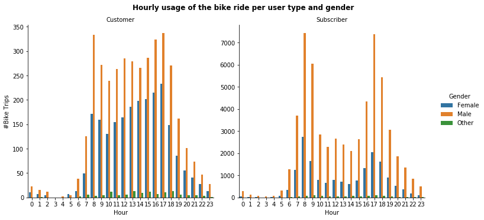

```python
# hourly usege of the bike sharing system per user type and gender

gr = sns.catplot(data=df_clean, x='start_time_hour', col="user_type", hue='member_gender', kind='count', sharey = False)
gr.set_axis_labels("Hour", "#Bike Trips")
gr._legend.set_title('Gender')
gr.set_titles("{col_name}")
gr.fig.suptitle('Hourly usage of the bike ride per user type and gender', y=1.03, fontsize=12, fontweight='semibold');
```

### Talk about some of the relationships you observed in this part of the investigation. Were there features that strengthened each other in terms of looking at your feature(s) of interest?

#### Resource

> https://seaborn.pydata.org/generated/seaborn.catplot.html

> https://www.lyft.com/bikes/bay-wheels